# CoronaIndiaEstimation

```python
%matplotlib inline
import matplotlib.pyplot as plt
import math
from datetime import datetime, timedelta, date
```

### Corona Growth Estimation for India (Naive estimation)

#### This experiment is to plot the data and find an approximate growth factor. Stupidity of people/government is not taken into consideration. Hence, this estimation doesn't include the possibility Social Gatherings.

**1-->2-->3-->5-->6-->29-->30-->31-->34-->39-->45-->50-->71-->76-->83-->95-->109-->120-->141-->171-->202** is the list of +ve corona cases daily from Jan 30th to March 19th.

```python
li = [1,2,3,5,6,29,30,31,34,39,45,50,71,76,83,95,109,120,141,171,202]

x = list(range(len(li)))
starting_date = date(2020, 3, 1)
dates = [(starting_date + timedelta(days=1+i)).strftime("%d%b") for i in range(len(li))]
dates = ['30Jan','1Feb','02Feb']+dates[:-3] #since the dates are not continuous

for i in range(5,len(dates)-1):dates[i]=dates[i][:2]
```

# How the data looks when plotted?

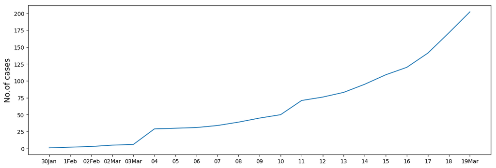

```python
from matplotlib.pyplot import figure
figure(num=None, figsize=(15, 5), dpi=100, facecolor='w', edgecolor='k')
plt.ylabel('No.of cases', fontsize=14)
plt.plot(dates,li)
```

### Rate of Growth

By what factor are the cases varying each day, in comparison to the previous day

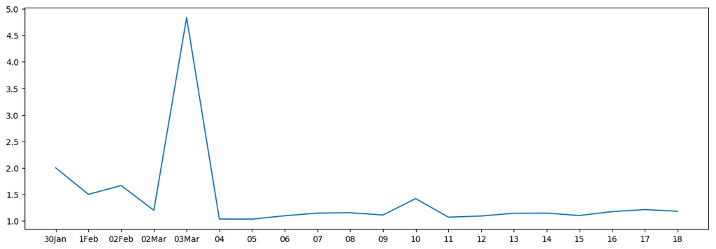

```python
dli = [li[i+1]/li[i] for i in range(len(li)-1)]
figure(num=None, figsize=(15, 5), dpi=100, facecolor='w', edgecolor='k')
plt.plot(dates[:-1],dli)
```

#### Taking an average of growth factors gives

```python
(sum(dli))/(len(dli))
```

```
1.4160525422505483
```

### Average growth rate is `1.4160525422505483`

### Checking correctness of the growth factor by comparing with the current data.

```python
latest = 1;avgfactor = 1.4160525422505483
exp_comps=[latest];
for i in range(len(li)-1): latest = latest*avgfactor;exp_comps.append(int(latest))
```

```python
for num in exp_comps: print(num,end="|")
```

```
1|1|2|2|4|5|8|11|16|22|32|45|65|92|130|184|261|370|524|742|1050|
```

## Well, by an average growth rate of `1.4160525422505483`, India should be having 1050 cases now but we have around 200. This problem can be attributed to the inconsistency in the data. After 2nd feb, we directly check for 2nd March. This resulted in a spike of 4.83 growth rate between two consecutive days. So, let's either

1. Remove 4.8 entry

OR

1. Start From 4th March

## 1. Removing 4.8 entry

```python
(sum(dli)-4.833333333333333)/(len(dli)-1)
```

```
1.2361956585093492
```

### Average growth rate is `1.2361956585093492`

### Checking correctness of the growth factor by comparing with the current data.

```python
latest = 1;avgfactor = 1.2361956585093492
exp_comps=[latest];
for i in range(len(li)-1): latest = latest*avgfactor;exp_comps.append(int(latest))
```

```python
for num in exp_comps: print(num,end="-->")
```

```
1-->1-->1-->1-->2-->2-->3-->4-->5-->6-->8-->10-->12-->15-->19-->24-->29-->36-->45-->56-->69-->
```

## 2. Start analysing from 4th March for consistency in data.

```python
li = [29,30,31,34,39,45,50,71,76,83,95,109,120,141,171,202]
starting_date = date(2020, 3, 3)
dates = [(starting_date + timedelta(days=1+i)).strftime("%d%b") for i in range(len(li))]


for i in range(5,len(dates)-1):dates[i]=dates[i][:2]
```

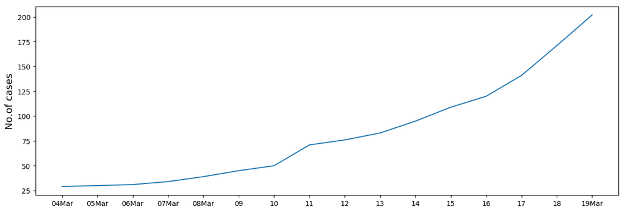

```python
from matplotlib.pyplot import figure
figure(num=None, figsize=(15, 5), dpi=100, facecolor='w', edgecolor='k')
plt.ylabel('No.of cases', fontsize=14)
plt.plot(dates,li)
```

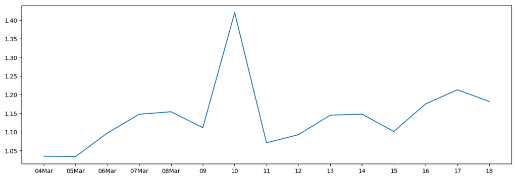

```python
dli = [li[i+1]/li[i] for i in range(len(li)-1)]
figure(num=None, figsize=(15, 5), dpi=100, facecolor='w', edgecolor='k')
plt.plot(dates[:-1],dli)
```

```python
(sum(dli))/(len(dli))
```

```
1.1414033896673978
```

### Average growth rate is `1.1414033896673978`

```python
latest = li[0];avgfactor = 1.1414033896673978
exp_comps=[latest];
for i in range(len(li)-1): latest = latest*avgfactor;exp_comps.append(int(latest))
```

```python
print("No.of cases using an average growth rate : ",exp_comps)
print("Actual  Number  of cases for  comparison : ",li)
```

```
No.of cases using an average growth rate :  [29, 33, 37, 43, 49, 56, 64, 73, 83, 95, 108, 124, 141, 161, 184, 210]
Actual  Number  of cases for  comparison :  [29, 30, 31, 34, 39, 45, 50, 71, 76, 83, 95, 109, 120, 141, 171, 202]
```

## That's almost similar. Let's use this rate for extrapolating the number of cases

## Expected growth rate for the next 10 days ?

```python
extrapolate = 20
```

```python
latest = li[-1];avgfactor = 1.1414033896673978
exp_comps=[latest];
for i in range(extrapolate): latest = latest*avgfactor;exp_comps.append(int(latest))
```

## With the current scenario, we can expect `758` cases in 10 days *i.e* by 29th March. And `2845` in 20 days *i.e* by 8th April.

Also, it is possible for the following trend to be followed,

#### 202--> 230--> 263--> 300--> 342--> 391--> 446--> 509--> 581--> 664--> 758--> 865--> 987--> 1127--> 1286--> 1468--> 1676--> 1913--> 2184--> 2492--> 2845

```python
dates = [(starting_date + timedelta(days=1+i)).strftime("%d%b") for i in range(len(li)+extrapolate)]
for i in range(5,len(dates)-1):dates[i]=dates[i][:2]
```

```python
newli = li[:-1]+exp_comps
```

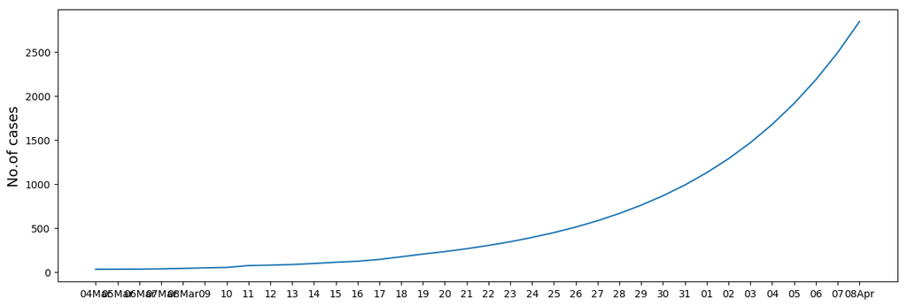

```python
figure(num=None, figsize=(15, 5), dpi=100, facecolor='w', edgecolor='k')
plt.ylabel('No.of cases', fontsize=14)
plt.plot(dates,newli)
```

## Find the `rate of change of growth`

Watch this extraordinary video https://www.youtube.com/watch?v=Kas0tIxDvrg to gain a mathematical perspective of the situation.

[figure not shown]

Video states that `No pandemic strictly follows an exponential growth but subsides after a certain point. This graph levels out when it comes to the size of population and is referred as Logistic Curve. And that certain point prior to decrease in growth is referred to as Inflection Point. Gradual decrease in the Growth factor means that the slope of growth is decreasing.`

### Calculating the Growth Factor is also mentioned in the video:

[figure not shown]

```python
totals = [29,30,31,34,39,45,50,71,76,83,95,109,120,141,171,202]

changes = [(li[i+1]-li[i]) for i in range(len(li)-1)]
changes
```

[output not shown]

```python
growth_factors = [changes[i+1]/changes[i] for i in range(len(changes)-1)]
growth_factors
```

[output not shown]

#### For India to reach the inflection point, the `blue plot` should go low beyond the `orange line` *i.e* the Growth factor <1 and is steadily decreasing. You may see a few points where `blue plot` is crossing the `Orange line`, but it too early for us to say we are beyond inflection point. Remember that the logistic curve works at the size of population. This is too early to be an indicator.

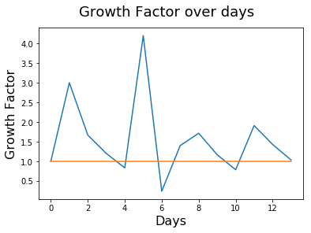

```python
fig = plt.figure()
fig.suptitle('Growth Factor over days', fontsize=18)
plt.xlabel('Days', fontsize=16)
plt.ylabel('Growth Factor', fontsize=16)

x = list(range(len(growth_factors)))
plt.plot(x,growth_factors)

# Base line 1 for slope consideration in the image above.
x_coordinates = list(range(len(growth_factors)))
y_coordinates = [1]*len(growth_factors)
plt.plot(x_coordinates, y_coordinates)
```